# VEGANScreener + metabolomics

Q5: Associations between PDI groups and the metabolome.

**This code explores patterns in the metabolome profiles of vegans, particularly by exploring associations with their dietary records (PDI groups).**

The script is divided into two parts, according to the integration method of metabolome datasets (see preprocessing scripts for details). At first, the **sPCA dataset** is analyzed. This dataset is used for multivariate analysis, PCA visualization, PERMANOVA and ML approach. The **concatenated dataset** of both LCMS and NMR is used for univariate analysis.

Prediction Goal: Predict metabolome from nutrition  
Question: Given someone’s diet, what metabolites do I expect to see?  
Type of Model: Forward modeling / Regression

Prediction Goal: Predict nutrition from metabolome  
Question: Can I infer what someone eats from their metabolome? Type of Model: Reverse modeling / Classification or Regression

The main parts of the analysis is composed of:

1. Canonical correlation analysis (CCA) - find linear combinations of **PDI groups** and metabolites that are maximally correlated. - SPCA
1. Predict Metabolome from Nutrition
2. Predict Nutrition from Metabolome
2. Mantel test - provides a global similarity measure - SPCA
3. Linear modeling - Metabolite ~ sex + bmi + age + country + **PDI_group**
4. Network analysis - bipartite graph, calculate degrees for nodes as **PDI groups**, nodes as metabolites. Identify communities in graphs thorugh Louvain method. Edges of the graph correspond to the significant associations (Estimates from LM).

# 1 Import

```r
metadata_df <- read.table(
  "../../data/preprocessed/dietary/veganscreener_preprocessed.tsv",
   header = TRUE)  %>%
  dplyr::filter(eq_included_group=="vegan")

lcms_df <- read.table("../../data/preprocessed/metabolomics/lc_ms_preprocessed.tsv",check.names = FALSE)
nmr_df <- read.table("../../data/preprocessed/metabolomics/nmr_preprocessed.tsv",check.names = FALSE)
spca_integrated_df <-  read.table("../../data/preprocessed/metabolomics/spca_integrated_all.tsv",
                                  check.names = FALSE)

pdi_df <- as.data.frame(fread("../../data/preprocessed/dietary/pdi_preprocessed_11.tsv")) %>% column_to_rownames("V1")
```

Remove outliers (other sex, bmi < 15)

```r
metadata_df <- metadata_df %>% dplyr::filter(bmi>15,sex != "OTHER")
```

**Get only important samples**

```r
# metabolomics
common_samples <- Reduce(intersect, list(rownames(lcms_df),
                                     rownames(nmr_df),
                                     rownames(spca_integrated_df),
                                     metadata_df$study_id,
                                     rownames(pdi_df)))

lcms_df <- lcms_df[common_samples,]
nmr_df <- nmr_df[common_samples,]
spca_integrated_df <- spca_integrated_df[as.character(common_samples),]
metadata_df <- metadata_df %>% dplyr::filter(study_id %in% common_samples)
pdi_df <- pdi_df[common_samples,]
```

# 2 Descriptive statistics

## 2.1 Metadata

Summary of counts per diet group, country and sex:

```r
metadata_df %>% dplyr::group_by(Country,sex) %>% count()
```

```
# A tibble: 10 × 3
# Groups:   Country, sex [10]
   Country sex       n
   <chr>   <chr> <int>
 1 BE      F        54
 2 BE      M        27
 3 CH      F        23
 4 CH      M        20
 5 CZ      F        37
 6 CZ      M        34
 7 DE      F        50
 8 DE      M        42
 9 ES      F        28
10 ES      M        15
```

Basic plots for visualizing the distribution of selected variables:

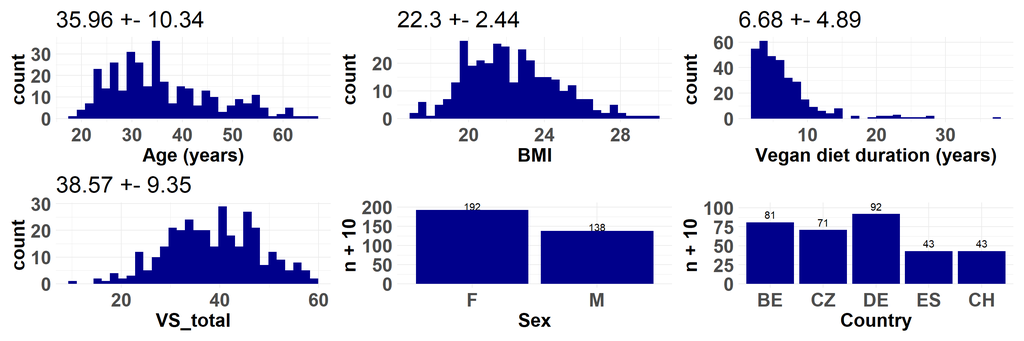

```r
plot_list <- list()
name <- c("Age (years)","BMI","Vegan diet duration (years)","VS_total")
i <- 1
for (col in c("age","bmi","eq_vegan_dur_total","VS_total")){
  p <- ggplot(metadata_df) +
    geom_histogram(aes(x=!!sym(col)),fill="darkblue") +
    theme_minimal() +
    theme(axis.title = element_text(face="bold",size=20),
          axis.text=element_text(face="bold",size=20),
          title = element_text(face = "plain",size=20)) +
    xlab(name[i]) +
    ggtitle(paste(round(mean(metadata_df[,col],na.rm = TRUE),2),"+-", round(sd(metadata_df[,col],na.rm = TRUE),2)))

  plot_list[[length(plot_list)+1]] <- p
  i <- i + 1

}
i <- 1
name <- c("Sex","Country")
for (col in c("sex","Country")){
  p <- ggplot(metadata_df) +
        theme_minimal() +
     theme(axis.title = element_text(face="bold",size=20),
          axis.text=element_text(face="bold",size=20)) +
  geom_text(data=metadata_df %>%
              dplyr::group_by(!!sym(col)) %>% count(), aes(x=!!sym(col),y=n+10,label=n)) +
    stat_count(aes(x=!!sym(col)),fill="darkblue") +
    xlab(name[i])

  plot_list[[length(plot_list)+1]] <- p

  i <- i+1
}

wrap_plots(plot_list)
```

## 2.2 PDI

Basic plots for visualizing the distribution:

[figure not shown]

```r
plot_list <- list()
name <- colnames(pdi_df)
i <- 1
for (col in name){
  p <- ggplot(pdi_df) +
    geom_histogram(aes(x=!!sym(col)),fill="darkblue") +
    theme_minimal() +
    theme(axis.title = element_text(face="bold",size=20),
          axis.text=element_text(face="bold",size=20),
          title = element_text(face = "plain",size=20)) +
    xlab(name[i]) +
    ggtitle(paste(round(mean(pdi_df[,col],na.rm = TRUE),2),"+-", round(sd(pdi_df[,col],na.rm = TRUE),2)))

  plot_list[[length(plot_list)+1]] <- p
  i <- i + 1

}

wrap_plots(plot_list)
```

```r
pdi_df <- pdi_df %>% rownames_to_column("study_id")
```

# 3 Concatenated dataset

```r
concat_integrated_df <- cbind(lcms_df,nmr_df)
```

## 3.1 Visualization

### 3.1.1 UMAP

```r
p1 <- umap_plot(concat_integrated_df,pdi_df,color_col = "hpdi_an",
          neighbors = 40,min_dist = 0.2)

p2 <- umap_plot(concat_integrated_df,pdi_df,color_col = "updi_an",
          neighbors = 40,min_dist = 0.2)

p <- p1 + p2

p
```

[output not shown]

### 3.1.2 PCA

```r
concat_plot_df <- merge(
  concat_integrated_df %>% rownames_to_column("study_id"),
  pdi_df,by="study_id")

p1 <- pca_plot(concat_integrated_df,
              pdi_df,
              color_col = "hpdi_an",
              perform_pca = TRUE)

p1 <- ggtheme(p1)

p2 <- pca_plot(concat_integrated_df,
              pdi_df,
              color_col = "updi_an",
              perform_pca = TRUE)

p2 <- ggtheme(p2)

p <- p1 + p2

p
```

[output not shown]

```r
concat_plot_df <- merge(
  concat_integrated_df %>% rownames_to_column("study_id"),
  pdi_df,by="study_id")

p1 <- pca_plot(concat_integrated_df,
              pdi_df,
              color_col = "hpdi_an",
              perform_pca = TRUE,axis = c("PC1","PC2"))

p1 <- ggtheme(p1)

p2 <- pca_plot(concat_integrated_df,
              pdi_df,
              color_col = "hpdi_an",
              perform_pca = TRUE,axis = c("PC2","PC3"))

p2 <- ggtheme(p2)

p3 <- pca_plot(concat_integrated_df,
              pdi_df,
              color_col = "hpdi_an",
              perform_pca = TRUE,axis = c("PC1","PC3"))

p3 <- ggtheme(p3)

p1 + p2 + p3 +
plot_layout(guides = "collect")
```

[output not shown]

```r
concat_plot_df <- merge(
  concat_integrated_df %>% rownames_to_column("study_id"),
  pdi_df,by="study_id")

p1 <- pca_plot(concat_integrated_df,
              pdi_df,
              color_col = "updi_an",
              perform_pca = TRUE,axis = c("PC1","PC2"))

p1 <- ggtheme(p1)

p2 <- pca_plot(concat_integrated_df,
              pdi_df,
              color_col = "updi_an",
              perform_pca = TRUE,axis = c("PC2","PC3"))

p2 <- ggtheme(p2)

p3 <- pca_plot(concat_integrated_df,
              pdi_df,
              color_col = "updi_an",
              perform_pca = TRUE,axis = c("PC1","PC3"))

p3 <- ggtheme(p3)

p1 + p2 + p3 +
plot_layout(guides = "collect")
```

[output not shown]

## 3.2 Mantel test

The Mantel test measures the correlation between two distance (or dissimilarity) matrices.

In our case:

Dataset 1: PDI profiles (e.g., pdi groups intake per client) Dataset 2: Metabolomic profiles (e.g., metabolite concentrations per client)

The Mantel test asks: Are clients who eat similarly also similar in their metabolome?

```r
#nutri <- pdi_df[,c(-19,-20)] %>% column_to_rownames("study_id")
nutri <- pdi_df[,c(-2)] %>% column_to_rownames("study_id")
# delete the zero variance columns
nutri <- nutri[,-which(apply(nutri, 2, var, na.rm = TRUE) == 0)]
```

### 3.2.1 Euclidean distance

**Simple Mantel test**

```r
# Compute distance matrices (e.g., Euclidean)
dist_nutri <- vegdist(nutri,method = "euclidean")
dist_metabo <-  vegdist(concat_integrated_df,method="euclidean")

# Mantel test
mantel_result <- mantel(dist_nutri, dist_metabo, method = "spearman", permutations = 999)
print(mantel_result)
```

```
Mantel statistic based on Spearman's rank correlation rho

Call:
mantel(xdis = dist_nutri, ydis = dist_metabo, method = "spearman",      permutations = 999)

Mantel statistic r: 0.07968
      Significance: 0.008

Upper quantiles of permutations (null model):
   90%    95%  97.5%    99%
0.0449 0.0582 0.0675 0.0766
Permutation: free
Number of permutations: 999
```

**Partial Mantel test**

The partial mantel is also a correlation test between two matrices, but controlling for the effect of a third distance matrix. This control is done by calculating the correlation between the residuals of each of the two main distance matrices after a linear regression on the third distance matrix.

```r
country_vec <- metadata_df$Country  # same order as in your data

dist_country <- as.dist(
  outer(country_vec, country_vec, FUN = Vectorize(function(x, y) as.numeric(x != y)))
)

mantel.partial(dist_nutri, dist_metabo, dist_country, permutations = 999,method = "pearson")
```

```
Partial Mantel statistic based on Pearson's product-moment correlation

Call:
mantel.partial(xdis = dist_nutri, ydis = dist_metabo, zdis = dist_country,      method = "pearson", permutations = 999)

Mantel statistic r: 0.09744
      Significance: 0.007

Upper quantiles of permutations (null model):
   90%    95%  97.5%    99%
0.0489 0.0691 0.0815 0.0895
Permutation: free
Number of permutations: 999
```

### 3.2.2 Manhattan distance

**Simple Mantel test**

```r
# Compute distance matrices (e.g., Euclidean)
dist_nutri <- vegdist(nutri,
                      method="manhattan")
dist_metabo <-  vegdist(concat_integrated_df,method="manhattan")

# Mantel test
mantel_result <- mantel(dist_nutri, dist_metabo, method = "spearman", permutations = 999)
print(mantel_result)
```

```
Mantel statistic based on Spearman's rank correlation rho

Call:
mantel(xdis = dist_nutri, ydis = dist_metabo, method = "spearman",      permutations = 999)

Mantel statistic r: 0.09499
      Significance: 0.004

Upper quantiles of permutations (null model):
   90%    95%  97.5%    99%
0.0381 0.0500 0.0606 0.0733
Permutation: free
Number of permutations: 999
```

**Partial Mantel test**

```r
country_vec <- metadata_df$Country  # same order as in your data

dist_country <- as.dist(
  outer(country_vec, country_vec, FUN = Vectorize(function(x, y) as.numeric(x != y)))
)

mantel.partial(dist_nutri, dist_metabo, dist_country, permutations = 999,method = "pearson")
```

```
Partial Mantel statistic based on Pearson's product-moment correlation

Call:
mantel.partial(xdis = dist_nutri, ydis = dist_metabo, zdis = dist_country,      method = "pearson", permutations = 999)

Mantel statistic r: 0.1072
      Significance: 0.003

Upper quantiles of permutations (null model):
   90%    95%  97.5%    99%
0.0429 0.0555 0.0660 0.0793
Permutation: free
Number of permutations: 999
```

## 3.3 Canonical correlation analysis (CCA)

https://www.karlin.mff.cuni.cz/~maciak/NMST539/cvicenie11.html

Canonical correlation analysis (CCA) is a multidimensional exploratory statistical method which operates on the same principle as the principal component analysis. The main purpose of the canonical correlation approach is the exploration of sample correlations between two sets of quantitative variables observed on the same experimental units. On the other hand PCA method deals with one data set only and it tries to to reduce the overall dimensionality of the dataset using some linear combination of the initial variables.

```r
library(CCA)

X <- nutri
Y <- concat_integrated_df

# Run Canonical Correlation Analysis
cca_model <- cc(X, Y)

# Canonical correlations
cca_model$cor
```

```
 [1] 0.7478724 0.6773754 0.6491089 0.6374440 0.5781643 0.5623272 0.5499260
 [8] 0.5318287 0.4963614 0.4303164 0.3938257 0.3736199 0.3548551
```

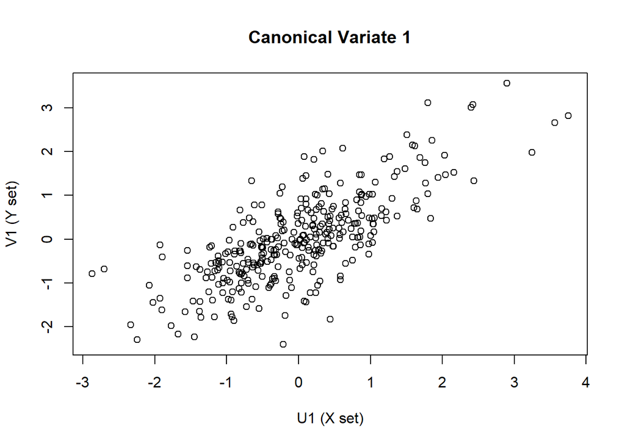

```r
plot(cca_model$scores$xscores[,1], cca_model$scores$yscores[,1],
     xlab="U1 (X set)", ylab="V1 (Y set)", main="Canonical Variate 1")
```

**Canonical Correlations barplot**

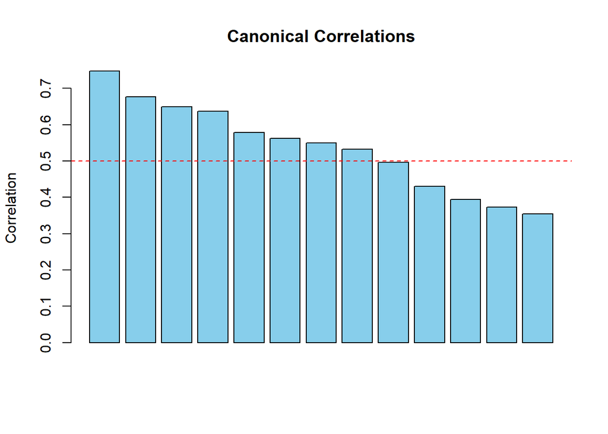

```r
barplot(cca_model$cor, main="Canonical Correlations", ylab="Correlation", col="skyblue")
abline(h=0.5, lty=2, col="red")
```

**Significance**

```r
# Significance testing
library(CCP)
sig <- p.asym(rho = cca_model$cor, N = nrow(X), p = ncol(X), q = ncol(Y), tstat = "Wilks")
```

```
Wilks' Lambda, using F-approximation (Rao's F):
                  stat    approx  df1       df2      p.value
1 to 13:   0.007279978 1.4660455 1001 3136.0547 7.105427e-15
2 to 13:   0.016519616 1.3177326  912 2906.7815 6.859557e-08
3 to 13:   0.030526159 1.2249769  825 2675.3247 1.186446e-04
4 to 13:   0.052753406 1.1399683  740 2441.7137 1.244496e-02
5 to 13:   0.088860533 1.0446189  657 2205.9864 2.393464e-01
6 to 13:   0.133479133 0.9843833  576 1968.1893 5.879701e-01
7 to 13:   0.195205411 0.9186339  497 1728.3795 8.761914e-01
8 to 13:   0.279831726 0.8399537  420 1486.6255 9.853662e-01
9 to 13:   0.390195245 0.7479005  345 1243.0083 9.994515e-01
10 to 13:  0.517757583 0.6569369  272  997.6230 9.999831e-01
11 to 13:  0.635419659 0.6096711  201  750.5792 9.999847e-01
12 to 13:  0.752063769 0.5823014  132  502.0000 9.998791e-01
13 to 13:  0.874077865 0.5585205   65  252.0000 9.969784e-01
```

```r
data.frame(Canonical = 1:length(cca_model$cor),
           Correlation = cca_model$cor,
           p.value = sig$p.value,
           sign=sig$p.value<0.05)
```

```
   Canonical Correlation      p.value  sign
1          1   0.7478724 7.105427e-15  TRUE
2          2   0.6773754 6.859557e-08  TRUE
3          3   0.6491089 1.186446e-04  TRUE
4          4   0.6374440 1.244496e-02  TRUE
5          5   0.5781643 2.393464e-01 FALSE
6          6   0.5623272 5.879701e-01 FALSE
7          7   0.5499260 8.761914e-01 FALSE
8          8   0.5318287 9.853662e-01 FALSE
9          9   0.4963614 9.994515e-01 FALSE
10        10   0.4303164 9.999831e-01 FALSE
11        11   0.3938257 9.999847e-01 FALSE
12        12   0.3736199 9.998791e-01 FALSE
13        13   0.3548551 9.969784e-01 FALSE
```

**Circle plot**

The circle is the unit circle in correlation space (radius = 1). Variables close to the circle edge are strongly correlated with the canonical axes (they contribute most). Variables near the center have weak contributions.

In other words, the direction and distance of a variable vector show: - Direction → which canonical axis it’s correlated with (positive/negative side). - Length → strength of the correlation.

Each axis represents a linear combination of original variables — one for the nutrient group (X), one for the metabolite group (Y).

Points: Each point in the plot represents a variable. Variables from X (nutrients) and Y (metabolites) are plotted in a shared space. Their coordinates correspond to correlations (loadings) between each original variable and the canonical variates.

If a nutrient variable (e.g. “fruit_juices”) lies near the metabolite X variable, it means they co-vary strongly in the canonical dimension. If two variables are close together, they are correlated. If they are on opposite sides of the origin, they are negatively correlated. Variables near the origin contribute little to that canonical function.

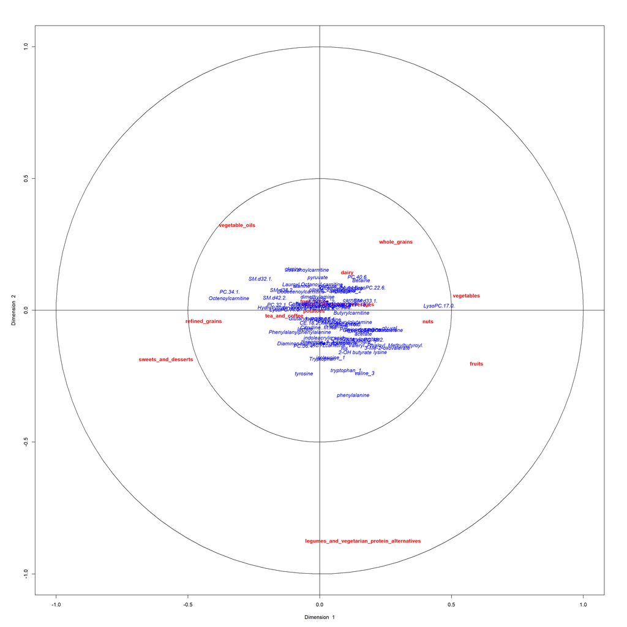

```r
plt.cc(cca_model, var.label = TRUE,type = "v")
```

**Loadings**

*First variate*

```r
# PDI groups
cca_model$xcoef[,c(1)][order(abs(cca_model$xcoef[,c(1)]),decreasing = TRUE)]
```

```
                        sweets_and_desserts
                                -0.47574983
                                 vegetables
                                 0.40147339
                                     fruits
                                 0.38979518
                                      dairy
                                 0.36331248
                                       nuts
                                 0.31289493
                             vegetable_oils
                                -0.27653593
                               whole_grains
                                 0.23002301
                             refined_grains
                                -0.13071460
                  sugar_sweetened_beverages
                                 0.11934838
                               fruit_juices
                                 0.05126637
                             tea_and_coffee
                                -0.02991169
legumes_and_vegetarian_protein_alternatives
                                 0.02508651
                                   potatoes
                                -0.02307338
```

```r
# metabolites groups
cca_model$ycoef[,c(1)][order(abs(cca_model$ycoef[,c(1)]),decreasing = TRUE)][1:20]
```

```
hydroxydecanoyl.carnitine hydroxyoctanoyl.carnitine              LysoPC.17.0.
                0.6274949                -0.6152157                 0.4501675
             LysoPC.22.6.        Diaminonaphthalene        3-Me-2-oxovalerate
                0.4088366                -0.3705262                 0.3609405
                 PC.34.1.                Tryptophan                  PC.32.1.
               -0.2891687                 0.2841092                 0.2637257
        Octenoylcarnitine         Glutamylglutamine                 Glutamine
               -0.2623673                 0.2543422                 0.2534456
             isoleucine_1                  PA.44.5.               glutamine_2
               -0.2279133                -0.2278038                -0.2269192
                glucose_4                 carnitine                       his
                0.1972008                 0.1953105                 0.1905495
             LysoPC.14.0.                   gly.val
               -0.1806129                 0.1804142
```

*Second variate*

```r
# PDI groups
cca_model$xcoef[,c(2)][order(abs(cca_model$xcoef[,c(2)]),decreasing = TRUE)]
```

```
legumes_and_vegetarian_protein_alternatives
                               -1.320328384
                               whole_grains
                                0.341872854
                                      dairy
                                0.215205009
                             vegetable_oils
                                0.209738906
                        sweets_and_desserts
                               -0.163518392
                                 vegetables
                                0.153466466
                             refined_grains
                               -0.129813531
                                     fruits
                               -0.128430738
                                       nuts
                               -0.078186926
                                   potatoes
                                0.074332198
                             tea_and_coffee
                                0.071404056
                               fruit_juices
                               -0.061942536
                  sugar_sweetened_beverages
                               -0.003233704
```

```r
# metabolites groups
cca_model$ycoef[,c(2)][order(abs(cca_model$ycoef[,c(2)]),decreasing = TRUE)][1:20]
```

```
              LysoPC.17.0.          Hexanoylcarnitine
                 0.6866492                  0.6788781
             dimethylamine                  citrate_2
                -0.6723266                  0.6204534
 hydroxydecanoyl.carnitine               LysoPC.18.2.
                 0.5683080                 -0.5663953
              LysoPC.22.6.                  SM.d33.1.
                 0.5647695                 -0.5029025
                   Betaine             LysoPC.P.16.0.
                 0.4703947                 -0.4221668
Lauroyl.Octanoyl.carnitine  hydroxyoctanoyl.carnitine
                -0.3797691                 -0.3410511
        Propionylcarnitine                   PA.44.5.
                -0.3374039                 -0.3332001
                 SM.d32.1.         indoleacrylic.acid
                 0.3302494                 -0.3210103
                  PC.32.1.        Dodecenoylcarnitine
                -0.3123378                 -0.3088581
                  PC.36.4.                 Tryptophan
                -0.3073593                  0.2934042
```

## 3.4 Network analysis

We want to model each metabolite as a function of sex, BMI, age, country, and each food group. Keep the estimated effect (and significance) of each food group on each metabolite.Then, we will use those significant effects to construct a bipartite network, where:

- one node type = metabolites
- other node type = food groups
- edges = significant relationships from the regression models.

```r
#nutri <- pdi_df[,c(-19,-20)] %>% column_to_rownames("study_id")
nutri <- pdi_df[,c(-2)] %>% column_to_rownames("study_id")
# delete the zero variance columns
nutri <- nutri[,-which(apply(nutri, 2, var, na.rm = TRUE) == 0)] %>%
  rownames_to_column("study_id")

metadata_for_lm <- merge(nutri,metadata_df,by="study_id",all=TRUE)
concat_for_uni <- merge(
  concat_integrated_df %>% rownames_to_column("study_id"),
  metadata_for_lm,
  by="study_id",all = TRUE)
```

### 3.4.1 LM

```r
results_list <- lapply(colnames(concat_integrated_df),
                       function(x) fit_netglm(x,concat_for_uni,
                                           tested_variable = "pdi_groups"))

results_df <- do.call(rbind, results_list)

results_df <- results_df %>%
  dplyr::mutate(p_adj = p.adjust(`p.value`, method = "BH"))

pdi_effects <- results_df %>% dplyr::filter(term %in% colnames(nutri))

concat_significant_cat <-  pdi_effects %>%
  filter(p_adj < 0.05)

concat_significant_cat
```

```
# A tibble: 18 × 7
   term                  estimate std.error statistic p.value Metabolite   p_adj
   <chr>                    <dbl>     <dbl>     <dbl>   <dbl> <chr>        <dbl>
 1 nuts                    -0.178    0.0617     -2.88 4.26e-3 PC.32.1.   4.72e-2
 2 sweets_and_desserts      0.197    0.0602      3.27 1.21e-3 PC.34.1.   1.80e-2
 3 nuts                     0.206    0.0612      3.36 8.67e-4 PC.36.2.   1.46e-2
 4 sweets_and_desserts     -0.227    0.0679     -3.34 9.44e-4 PC.38.4.   1.57e-2
 5 fruits                   0.120    0.0344      3.49 5.47e-4 LysoPC.17… 1.06e-2
 6 sweets_and_desserts     -0.228    0.0365     -6.24 1.40e-9 LysoPC.17… 1.19e-7
 7 refined_grains           0.167    0.0556      3.01 2.86e-3 LysoPC.14… 3.58e-2
 8 fruits                   0.153    0.0494      3.10 2.09e-3 Uric.acid  2.77e-2
 9 fruits                  -0.149    0.0448     -3.32 1.02e-3 Octenoylc… 1.61e-2
10 refined_grains           0.118    0.0412      2.86 4.47e-3 Octenoylc… 4.88e-2
11 vegetable_oils           0.193    0.0436      4.42 1.36e-5 Octenoylc… 4.69e-4
12 nuts                     0.194    0.0605      3.21 1.45e-3 O.ERGOthi… 2.11e-2
13 fruits                   0.202    0.0585      3.46 6.20e-4 Phenylbut… 1.10e-2
14 legumes_and_vegetari…    0.439    0.0888      4.95 1.24e-6 phenylala… 5.71e-5
15 legumes_and_vegetari…    0.250    0.0792      3.16 1.75e-3 2-oxoisoc… 2.45e-2
16 legumes_and_vegetari…    0.287    0.0812      3.54 4.61e-4 acetate    9.31e-3
17 legumes_and_vegetari…    0.271    0.0713      3.80 1.74e-4 valine_3   4.19e-3
18 legumes_and_vegetari…    0.301    0.0871      3.46 6.14e-4 2-OH buty… 1.10e-2
```

### 3.4.2 Graph construction

**Edge list**

```r
edges <- pdi_effects %>%
  dplyr::filter(p_adj < 0.05) %>%
  dplyr::select(from = term, to = Metabolite,
         estimate = estimate) %>%
  dplyr::mutate(from=as.character(from),
         weight=abs(estimate))

edges$from <- as.character(edges$from)
edges$to   <- as.character(edges$to)
```

**Nodes table**

```r
pdis <- as.character(unique(edges$from))
metabs <- as.character(unique(edges$to))

nodes <- data.frame(
  name = c(pdis, metabs),
  type = c(rep(TRUE, length(pdis)), rep(FALSE, length(metabs))) # TRUE = tertile, FALSE = metabolite
)
```

**Build igraph object**

```r
g <- graph_from_data_frame(d = edges, vertices = nodes, directed = FALSE)
```

**Visualize**

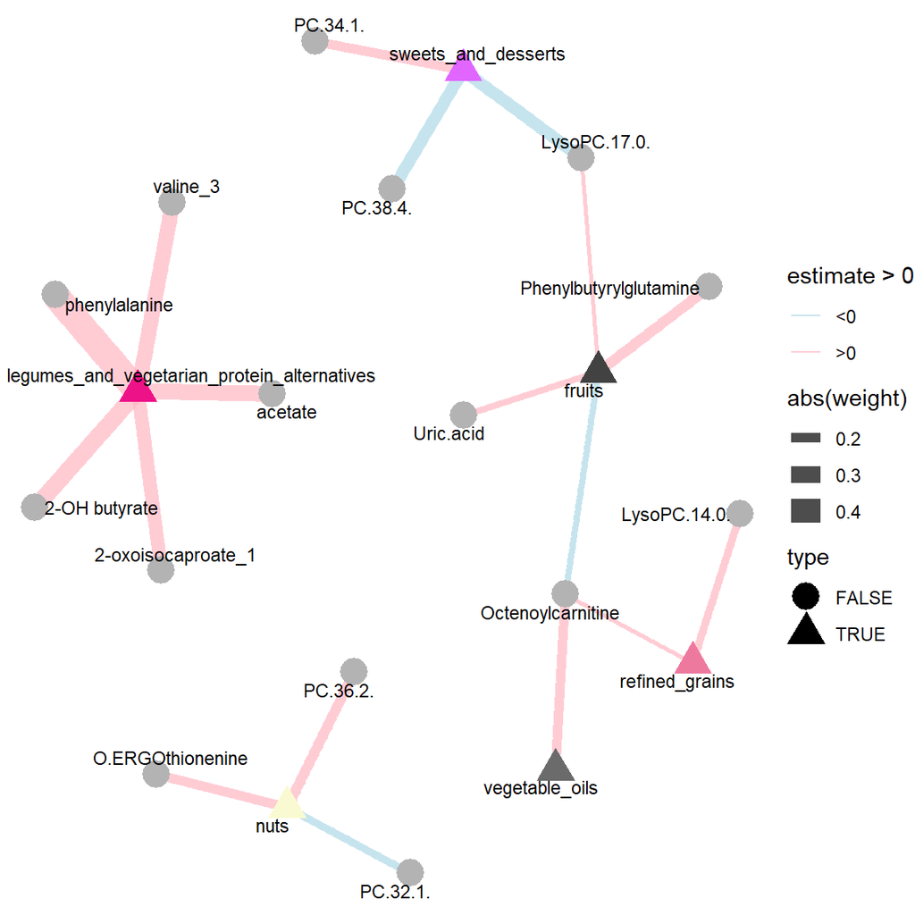

```r
set.seed(123)
pdi_colors <- sample(colors(), sum(nodes$type))
names(pdi_colors) <- nodes$name[nodes$type]

# Assign colors to nodes: countries get their color, metabolites gray
V(g)$color <- ifelse(V(g)$type,
                     pdi_colors[V(g)$name],
                     "gray70")

set.seed(123)
ggraph(g, layout = "fr") +
  geom_edge_link(aes(width = abs(weight), color = estimate > 0), alpha = 0.7) +
  scale_edge_color_manual(values = c("lightblue", "lightpink"), labels = c("<0", ">0")) +
  geom_node_point(aes(shape=type,color = name), size = 6) +
  scale_color_manual(values = setNames(V(g)$color, V(g)$name)) +  # node colors
  geom_node_text(aes(label = name), repel = TRUE, size = 3) +
  theme_void() +
  guides(color = "none")
```

## 3.5 glmnet

### 3.5.1 PDI groups -> metabolites

```r
X <- as.matrix(nutri %>% column_to_rownames("study_id"))
Y <- as.matrix(concat_integrated_df)

model_glmnet <- make_glmnet_model(X,Y)
```

To consider model to be well fitted, we would expect following values: R² > 0.5 (ideally closer to 0.7–0.8) Correlation (r) > 0.6 RMSE As low as possible (relative to Y scale)

```r
results_df_model <- data.frame(
  r2=colMeans(do.call(rbind, model_glmnet$valid_performance$r2)),
  corr=colMeans(do.call(rbind, model_glmnet$valid_performance$corr)),
  rmse=colMeans(do.call(rbind, model_glmnet$valid_performance$rmse))
)

results_df_model
```

```
                                                             r2         corr
PC.20.3.OH.P.18.1.                                -0.0237511354  0.009109479
PC.P.38.4.                                        -0.0426620324 -0.054135190
Caffeine                                           0.0135373977  0.163945547
CE.18.2..M.NH4..                                  -0.0324715751 -0.057979433
PC.36.4.                                          -0.0077872941  0.046594121
PA.44.5.                                           0.0003721969  0.070475408
PC.32.1.                                           0.0193298428  0.207497911
PC.34.1.                                           0.0416882255  0.266237775
PC.36.2.                                           0.0014407663  0.135883997
PC.38.4.                                           0.0004495399  0.076140000
PC.40.6.                                           0.0081155424  0.124883831
PC.P.38.4..PC.O.38.5.                             -0.0062121704  0.059708636
SM.d38.2.                                          0.0096023409  0.146686170
SM.d42.2.                                          0.0049080404  0.129384299
SM.d33.1.                                          0.0272000521  0.220771077
SM.d34.1.                                         -0.0173373676 -0.046042188
LysoPC.22.6.                                       0.0096447420  0.153508552
SM.d32.1.                                          0.0293670285  0.220293605
LysoPC.P.16.0.                                    -0.0255819615  0.030309076
indoleacrylic.acid                                -0.0132713733  0.071552928
LysoPC.17.0.                                       0.1330764624  0.450299955
LysoPC.18.2.                                       0.0169817683  0.169289699
Dodecenoylcarnitine                               -0.0268838513 -0.001720532
LysoPC.14.0.                                       0.0136241645  0.170003189
Uric.acid                                          0.0026797688  0.159881440
Lauroyl.Octanoyl.carnitine                        -0.0281680332  0.011279612
Octenoylcarnitine                                  0.0647527153  0.351133226
Hexanoylcarnitine                                 -0.0117705492  0.078810715
hydroxydecanoyl.carnitine                         -0.0191011259  0.067310205
ACYLcarnitine..Valeryl..Pivaloyl..Methylbutyroyl.  0.0062738053  0.131717680
hydroxyoctanoyl.carnitine                         -0.0177715105  0.066657650
Butyrylcarnitine                                   0.0068331567  0.122408781
Phenylalanylphenylalanine                         -0.0048364753  0.089589033
Propionylcarnitine                                -0.0118225489  0.074696612
Betaine                                           -0.0041397602  0.106862660
Tryptophan                                        -0.0147845500  0.058946880
Diaminonaphthalene                                -0.0115916979  0.026076041
Creatinine                                        -0.0122953771  0.081211476
Glutarylcarnitine                                 -0.0053824040  0.134654930
```

[output cut: 101 more lines]

```
asparagine_2                                      0.9750006
methylguanidine                                   0.9011376
dimethylamine                                     0.9588904
X2.oxoisocaproate_1                               0.9331482
citrate_2                                         0.9732833
pyruvate                                          0.9914702
X3.hydroxybutyrate_3                              0.9982731
acetone                                           1.0186426
glutamine_2                                       1.0190128
acetate                                           1.0420658
alanine                                           0.9969119
X3.Me.2.oxovalerate                               0.9717959
valine_3                                          0.9103784
isoleucine_1                                      0.9639954
X2.OH.butyrate                                    0.9943966
```

### 3.5.2 metabolites -> PDI groups

```r
Y <- as.matrix(nutri %>% column_to_rownames("study_id"))
X <- as.matrix(concat_integrated_df)

model_glmnet <- make_glmnet_model(X,Y)
```

To consider model to be well fitted, we would expect following values: R² > 0.5 (ideally closer to 0.7–0.8) Correlation (r) > 0.6 RMSE As low as possible (relative to Y scale)

```r
results_df_model <- data.frame(
  r2=colMeans(do.call(rbind, model_glmnet$valid_performance$r2)),
  corr=colMeans(do.call(rbind, model_glmnet$valid_performance$corr)),
  rmse=colMeans(do.call(rbind, model_glmnet$valid_performance$rmse))
)

results_df_model
```

```
                                                      r2         corr      rmse
dairy                                       -0.064227430  0.047746472 0.4467669
fruit_juices                                -0.075618196  0.008353139 0.7971644
fruits                                       0.091435641  0.326375649 0.9127569
legumes_and_vegetarian_protein_alternatives  0.124362882  0.369195538 0.6438313
nuts                                         0.007568895  0.188023947 0.8551859
potatoes                                    -0.117155453 -0.030243328 0.8630851
refined_grains                               0.061623765  0.278714354 1.0583855
sugar_sweetened_beverages                   -0.171614202 -0.109611875 0.5775502
sweets_and_desserts                          0.062313502  0.327223933 0.8725805
tea_and_coffee                               0.028722610  0.200732535 0.9408303
vegetable_oils                              -0.020278248  0.177906561 0.9221867
vegetables                                   0.045013208  0.250329874 0.8653267
whole_grains                                 0.038561327  0.233550923 0.9100732
```